# Predykcja sprzedaży

# Wstęp

Celem poniższej analizy jest eksploracja danych sprzedażowych oraz predykcja tygodniowej sprzedaży poszczególnych sklepów, a tym samym całej sieci.

# Analiza wstępna

## Wczytanie danych

```r
# ###################################################################
# Libraries
# ###################################################################
library(dplyr)
library(tidyr)
library(purrr)
library(readr)
library(ggplot2)
library(lubridate)

options(stringsAsFactors = F)
# ###################################################################
# Working directory
# ###################################################################
work_dir <- "D:/Osobiste/analizy/sales_prediction/"

# ###################################################################
# Reading files
# ###################################################################
train_data <- read.csv(paste0(work_dir, "data/train.csv")) %>%
    dummies::dummy.data.frame(names = c("StateHoliday"), sep = "_", all = T) %>%
    mutate(SundayOpen = ifelse(DayOfWeek == 7 & Open == 1, 1, 0))
stores_data <- read.csv(paste0(work_dir, "data/store.csv"))
```

## Podstawowe statystyki

Dostarczone zbiory zawierają dane dla 1115 sklepów z 942 różnych dni. Na podstawie zamieszczonego wykresu można zauważyć, że wartość dziennej sprzedaży nie ma rozkładu normalnego.

```r
# ###################################################################
# Statistics
# ###################################################################
stores_num <- train_data %>%
    distinct(Store) %>%
    nrow()
print(stores_num)
```

```
[1] 1115
```

```r
days_num <- train_data %>%
    distinct(Date) %>%
    nrow()
print(days_num)
```

```
[1] 942
```

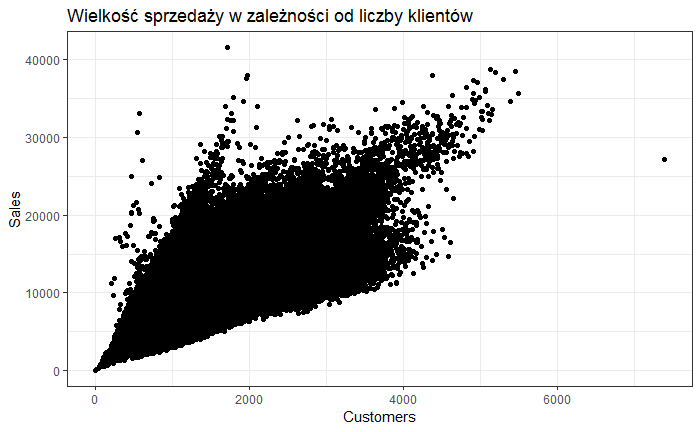

```r
# ###################################################################
# Plot data
# ###################################################################
ggplot(subset(train_data, Sales > 0))+
    geom_point(aes(x = Customers, y = Sales))+
    labs(title = "Wielkość sprzedaży w zależności od liczby klientów")+
    theme_bw()
```

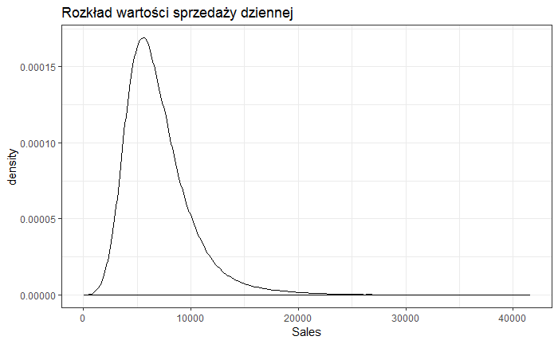

```r
ggplot(subset(train_data, Sales > 0))+
    geom_density(aes(x =  Sales, y = ..density..))+
    labs(title = "Rozkład wartości sprzedaży dziennej")+
    theme_bw()
```

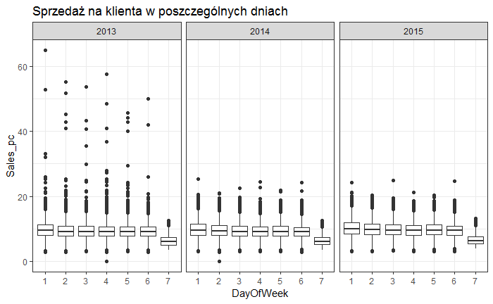

```r
# ###################################################################
# Sales per day
# ###################################################################
week_stats <- train_data %>%
    separate(Date, into = c("year", "month", "day"), sep = "-") %>%
    mutate(Sales_pc = Sales / Customers,
           DayOfWeek = DayOfWeek %>% as.character())

ggplot(week_stats, aes(y=Sales_pc, x = DayOfWeek, group=DayOfWeek))+
    labs(title = "Sprzedaż na klienta w poszczególnych dniach")+
    geom_boxplot()+
    facet_wrap(~year)+
    theme_bw()
```

Analizując powyższy wykres można zauważyć, że wartość sprzedaży przypadająca na jednego klienta jest stała od poniedziałku do soboty. Natomiast średnia wartość paragonu w niedzielę jest wyraźnie niższa. Może mieć to różne przyczy. Po pierwsze nie wszystkie sklepy są otwarte w niedzielę, tak więc może okazać się że otwarte są jedynie mniejsze sklep. Z drugiej strony, jest możliwe że w niedzielę do sklepów przychodzą osoby, które *czegoś zapomniały* w tygodniu.

# Grupowanie

W dalszej części analizy, na podstawie cech charakterystycznych sklepów tj. odległości od konkurencji, uczestnictwa w promocjach kuponowych (Promo2) oraz dziennej wielkość sprzedaży i średniej wartości paragonu, wyodrębniono jednorodne grupy sklepów.

Wyniki algorytmu **silhouette** wskazują na to, że wśród badnych sklepów można wyszczególnić pięć grup. Pierwsza z nich, to sklepy o dużej odległości od konkurencji. Kolejna charakteryzuje się relatywnie niewielką odległością od konkurencji, ale nie prowadzi promocji kuponowych. Trzecia grupa to natomiast sklepy o najmniejszej odległości od konurencji, prowadzące promocje kuponowe i jednocześnie najniższej średniej wartości paragonu. Na czwartą grupę składają się sklepy o największej wartości sprzedaży na klienta, ich konkurencja znajduje się w większej odległości i większość z nich bierze udział w promocjach kuponowych. Do ostatniej grupy należą sklepy o wysokiej wartości dziennego obrotu, mające blisko siebie konkurencję i niebiorące udziału w regularnych promocjach.

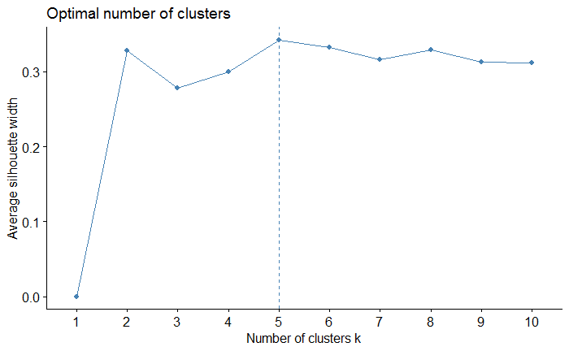

```r
# ###################################################################
# Clustering
# ###################################################################
stores_stats <- train_data %>%
    mutate(Sales_pc = Sales / Customers) %>%
    filter(Sales > 0) %>%
    filter(! is.na(Sales_pc)) %>%
    group_by(Store) %>%
    summarise(Sales_pc = mean(Sales_pc),
              Sales = mean(Sales))

cluster_data <- stores_data %>%
    dplyr::select(Store,
                  CompetitionDistance,
                  Promo2) %>%
    left_join(stores_stats, by = "Store") %>%
    na.omit() %>%
    dplyr::select(-Store)

cluster_data_scaled <- cluster_data %>%
    scale() %>%
    as.data.frame()
data <- cluster_data_scaled

set.seed(4)
factoextra::fviz_nbclust(data, kmeans, method = "silhouette")
```

```r
# Optymalne jest 5 clustrow


# Srednie wartosci dla poszczegolnych grup
set.seed(4)
stores_cluster <- kmeans(cluster_data_scaled, 5)
cluster_data$cluster <- stores_cluster$cluster
cluster_stats <- cluster_data %>%
    group_by(cluster) %>%
    summarise_all(mean) %>%
    left_join(cluster_data %>%
                  group_by(cluster) %>%
                  summarise(counts = n()), by = "cluster")
cluster_stats
```

| cluster | CompetitionDistance | Promo2 | Sales_pc | Sales | counts |
| --- | --- | --- | --- | --- | --- |
| 1 | 23648.600 | 0.0900000 | 9.757142 | 6653.121 | 100 |
| 2 | 3043.668 | 0.0000000 | 8.792154 | 6334.566 | 349 |
| 3 | 2005.631 | 1.0000000 | 8.639382 | 6095.663 | 309 |
| 4 | 7014.575 | 0.9473684 | 12.049225 | 6786.218 | 247 |
| 5 | 2157.103 | 0.1682243 | 8.652908 | 11964.293 | 107 |

# Predykcja

Na potrzeby tego zadania, w predykcji nie zostaną wykorzystane wyodrębnione grupy. W prawdziwej analizie należałoby przetestować czy lepszych wyników nie daje zbudowanie oddzielnych modeli dla każdej z wyodrębnionej grupy.

Zadaniem przedstawionych modeli predykcyjnych (regresja liniowa i XGBoost) jest przewidywanie sprzedaży poszczególnych sklepów w kolejnym tygodniu kalendarzowym, liczonym od poniedziałku do niedzieli. W obu modelach zastosowano przekształcenie znane w ekonometrii panelowej jako *Fixed Effects (FE)*. Modele FE zakładają że w przypadku każdej jednostki mamy do czynienia ze stałym dla niej efektem, który wpływa na objaśnianą zmienną, w tym wypadku na logarytm wartośći sprzedaży. Aby wyestymować model FE za pomocą zykłej regresji liniowej, bez dodania zmiennych biarnych dla każdej jednostki, wystarczy od każdej zmiennej objaśniającej oraz od objaśnianej odjąć średnią wartość danej cechy dla danej jednostki (sklepu).

## Przekształcenie zbioru

```r
# ###################################################################
# Przeksztalcenie zbioru do predykcji
# ###################################################################
dominant <- function(x){
    tab <- table(x)
    y <- which.max(tab)
    return(names(y))
}

scale_function <- function(x) x - mean(x, na.rm = T)

# Dodanie informacji o Promo2
promo_2_data <- stores_data %>%
    filter(Promo2 == 1) %>%
    mutate(Promo2SinceWeek = Promo2SinceWeek + (Promo2SinceYear-2013)*52) %>%
    dplyr::select(Store, PromoInterval, Promo2SinceWeek) %>%
    tidyr::separate(PromoInterval, into=c("month_1", "month_2", "month_3", "month_4")) %>%
    gather(key = "key", value = "promo2_month", -Store, -Promo2SinceWeek) %>%
    mutate(promo2_month = ifelse(promo2_month=="Sept", "Sep", promo2_month),
           promo2_month = readr::parse_date(paste0("02-", promo2_month, "-2015"), format = "%d-%b-%Y", locale = locale("en")) %>%
                          format("%m") %>% as.numeric()) %>%
    dplyr::select(-key) %>%
    mutate(Promo2 = 1) %>%
    rename(month = promo2_month)

# Agregacja i modyfikacja zbioru
train_data_weeks <- train_data %>%
    separate(Date, into = c("year", "month", "day"), sep = "-", remove = F) %>%
    mutate(week_num = as.Date(Date, "%Y-%m-%d") %>% format("%V"), # Tutaj poczatek tygodnia jest w poniedzialek
           date = as.Date(Date, "%Y-%m-%d")) %>%
    mutate(year = year %>% as.numeric(),
           week_num = week_num %>% as.numeric(),
           year = ifelse((week_num == 1) & (month == 12), year + 1, year),
           month = ifelse((week_num == 1) & (month == 12), 1, month) %>% as.numeric()) %>%
    filter(! ((week_num == 1) & (year == 2013))) %>%
    filter(! ((week_num == 31) & (year == 2015))) %>%
    mutate(week_num = week_num + 52*(year-2013)) %>%
    # Dodanie informacji o Promo2
    left_join(promo_2_data, by = c("Store", "month")) %>%
    mutate(Promo2 = ifelse(is.na(Promo2), 0,
                           ifelse(week_num < Promo2SinceWeek, 0, Promo2))) %>%
    dplyr::select(-Promo2SinceWeek) %>%
    # Agregacja
    group_by(Store, week_num) %>%
    summarise(Sales = sum(Sales), date = min(date), SundayOpen = sum(SundayOpen),
              Promo = mean(Promo), Open = sum(Open), StateHoliday_0 = sum(StateHoliday_0),
              StateHoliday_a = sum(StateHoliday_a), StateHoliday_b = sum(StateHoliday_b),
              StateHoliday_c = sum(StateHoliday_c), SchoolHoliday = mean(SchoolHoliday),
              month = dominant(month), year = dominant(year), Promo2 = mean(Promo2)) %>%
    group_by(Store) %>%
    mutate(Sales_log = log(Sales)) %>%
    arrange(date) %>%
    filter(! is.na(Sales_log) & Sales > 0) %>%
    mutate(Sales_log_lag = dplyr::lag(Sales_log)) %>%
    ungroup() %>%
    data.frame() %>%
    dummies::dummy.data.frame(names = c("month"), sep = "_", all = T) %>%
    group_by(Store)
```

## Przeciętna sprzedaż tygodniowa

Poniższy wykres przedstawia przeciętną sprzedaż tygodniową. Obserwacje podzielono na dwie grupy. W pierwszej znalazły się sklepy, które przez mniej niż 4 dni w tygodniu prowadziły promocje (Promo).

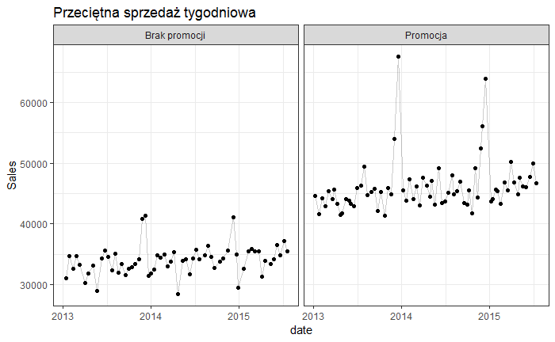

```r
weekly_stats <- train_data_weeks %>%
    filter((Sales > 0)) %>%
    mutate(Promo = ifelse(Promo > 0.5, "Promocja", "Brak promocji")) %>%
    group_by(week_num, Promo) %>%
    summarise(Sales = mean(Sales), date = min(date))

ggplot(weekly_stats, aes(x = date, y = Sales))+
    labs(title = "Przeciętna sprzedaż tygodniowa")+
    geom_point()+
    geom_line(alpha=.2)+
    facet_grid(~Promo)+
    theme_bw()
```

## Podział na zbiór treningowy i testowy

Ze względu na to że dane są szeregiem czasowym, nie można losowo dobrać zbioru uczącego i testowego. Przyjęto, że w pierwszym znajdą się obserwacje ze 110 pierwszych tygodni, pozostałe zaś trafiły do zbioru testowego.

```r
test_data_weeks <- train_data_weeks %>%
    filter(week_num > 110)

train_data_weeks <- train_data_weeks %>%
    filter(week_num <= 110)
```

## Transformacja FE

```r
mean_na_rm <- function(x) mean(x, na.rm = T)
stores_means <- train_data_weeks %>%
    dplyr::select(Store, Sales_log, Sales_log_lag, SundayOpen, Promo, Promo2,
                  Open, starts_with("State"), SchoolHoliday, matches("month")) %>%
    group_by(Store) %>%
    summarise_all(mean_na_rm)

col_names <- colnames(stores_means)
col_names <- paste0(col_names, "_mean")
colnames(stores_means) <- col_names

test_data_weeks <- test_data_weeks %>%
    left_join(stores_means, by = c("Store" = "Store_mean")) %>%
    mutate(Sales_log = Sales_log - Sales_log_mean,
           Sales_log_lag = Sales_log_lag - Sales_log_lag_mean,
           SundayOpen = SundayOpen - SundayOpen_mean,
           Promo_real = Promo,
           Promo = Promo - Promo_mean,
           Promo2 = Promo2 - Promo2_mean,
           Open = Open - Open_mean,
           StateHoliday_0 = StateHoliday_0 - StateHoliday_0_mean,
           StateHoliday_a = StateHoliday_a - StateHoliday_a_mean,
           StateHoliday_b = StateHoliday_b - StateHoliday_b_mean,
           StateHoliday_c = StateHoliday_c - StateHoliday_c_mean,
           SchoolHoliday = SchoolHoliday - SchoolHoliday_mean)

train_data_weeks <- train_data_weeks %>%
    group_by(Store) %>%
    mutate_at(vars(Sales_log, Sales_log_lag, SundayOpen, Promo, Promo2, Open, matches("Holiday"), matches("month")), scale_function)
```

## Regresja liniowa

Interpretując wyniki regresji liniowej należy pamiętać o tym, że uzyskane parametry mogą być obciążone ze względu na uwzględnienie w modelu opóźnienia zmiennej objaśnianej. Aby uzyskać nieobciążone oszacowania, należałoby wyestymować panel dynamiczny. Niestety obcenie dostępne pakiety w R nie pozwalają na efektywną estymację modeli dynamicznych dla dużych zbiorów danych.

Niemniej, można zauważyć że zgodnie z przewidywaniami promocje specjalne zwiększają wartość sprzedaży i to aż o 50%. Z kolei promocje kuponowe nieznacznie zmniejszają tygodniowy poziom sprzedaży (-0,3%).

```r
model_FE <- lm(Sales_log ~ Sales_log_lag + SundayOpen + Promo + Promo2 + StateHoliday_a + StateHoliday_b +
                   StateHoliday_c + SchoolHoliday,
               data = train_data_weeks)
model_FE %>% summary()
```

```
Call:
lm(formula = Sales_log ~ Sales_log_lag + SundayOpen + Promo +
    Promo2 + StateHoliday_a + StateHoliday_b + StateHoliday_c +
    SchoolHoliday, data = train_data_weeks)

Residuals:
     Min       1Q   Median       3Q      Max
-2.77425 -0.06911 -0.00390  0.06594  1.30182

Coefficients:
                 Estimate Std. Error t value Pr(>|t|)
(Intercept)     0.0006222  0.0003920   1.587  0.11246
Sales_log_lag   0.2545404  0.0025167 101.142  < 2e-16 ***
SundayOpen      0.1868201  0.0068349  27.333  < 2e-16 ***
Promo           0.5064268  0.0014154 357.795  < 2e-16 ***
Promo2         -0.0037829  0.0013212  -2.863  0.00419 **
StateHoliday_a -0.0421020  0.0012408 -33.930  < 2e-16 ***
StateHoliday_b -0.0780462  0.0021774 -35.844  < 2e-16 ***
StateHoliday_c -0.0579574  0.0016421 -35.294  < 2e-16 ***
SchoolHoliday  -0.0325762  0.0013961 -23.334  < 2e-16 ***
---
Signif. codes:  0 ‘***’ 0.001 ‘**’ 0.01 ‘*’ 0.05 ‘.’ 0.1 ‘ ’ 1

Residual standard error: 0.1333 on 115714 degrees of freedom
  (1115 observations deleted due to missingness)
Multiple R-squared:  0.5983,    Adjusted R-squared:  0.5983
F-statistic: 2.154e+04 on 8 and 115714 DF,  p-value: < 2.2e-16
```

```r
# Predykcja
test_data_weeks$prediction_fe <- predict(model_FE, test_data_weeks)

test_data_weeks <- test_data_weeks %>%
    mutate(prediction_fe = exp(prediction_fe + Sales_log_mean),
           res_fe = Sales - prediction_fe)
```

## XGBoost

### Hiperparametryzacja

Na podstawie optymalizacji hiperparametrów najlepsze okazały się następujące parametry: eta - 0,25, max_depth - 7 oraz gamma równa zero.

```r
# ###################################################################
# XGBoost
# ###################################################################
library(caret)
# Tuning
tune_grid <- expand.grid(
    nrounds = 200,
    eta = c(0.1, 0.25, 0.5, 0.75),
    max_depth = c(3, 5, 7),
    gamma = c(0, 5, 10),
    colsample_bytree = 1,
    min_child_weight = 1,
    subsample = 1
)

tune_control <- caret::trainControl(
    method = "cv", # cross-validation
    number = 3,
    verboseIter = FALSE,
    allowParallel = TRUE
)
input_x <- as.matrix(select(ungroup(train_data_weeks),
                            Sales_log_lag, SundayOpen, Promo, Promo2, Open, matches("Holiday")))
input_y <- train_data_weeks$Sales_log

xgb_tune <- caret::train(
    x = input_x,
    y = input_y,
    trControl = tune_control,
    tuneGrid = tune_grid,
    method = "xgbTree",
    verbose = TRUE
)
```

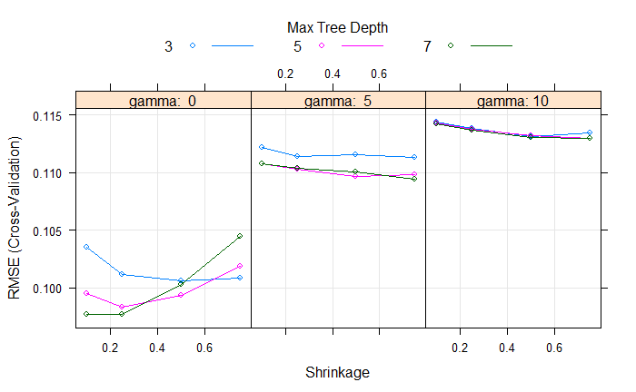

```r
plot(xgb_tune)
```

### Estymacja modelu

```r
# Estimation
library(xgboost)
train_data_xgb <- train_data_weeks %>%
    dplyr::select(-matches("month")) %>%
    filter(week_num <= 95) %>%
    ungroup() %>%
    dplyr::select(Sales_log, Sales_log_lag, SundayOpen, Promo, Promo2, Open, matches("Holiday"))

tuning_data_xgb <- train_data_weeks %>%
    dplyr::select(-matches("month")) %>%
    filter(week_num > 95) %>%
    ungroup() %>%
    dplyr::select(Sales_log, Sales_log_lag, SundayOpen, Promo, Promo2, Open, matches("Holiday"))

test_data_xgb <- test_data_weeks %>%
    dplyr::select(-matches("month")) %>%
    ungroup() %>%
    dplyr::select(Sales_log, Sales_log_lag, SundayOpen, Promo, Promo2, Open, matches("Holiday"))

# Sparse Matrix - training
samp_matrix <- as.matrix(train_data_xgb[-which(colnames(train_data_xgb) == "Sales_log")])
X_spm <- as(samp_matrix, "dgCMatrix")
xgb_matrix_train <- xgb.DMatrix(label = train_data_xgb[["Sales_log"]], data = X_spm)
rm(samp_matrix, X_spm)
gc(reset = T)
```

```
           used  (Mb) gc trigger   (Mb) max used  (Mb)
Ncells  3688419 197.0    7772159  415.1  3688419 197.0
Vcells 66831176 509.9  181283618 1383.1 66831176 509.9
```

```r
samp_matrix <- as.matrix(tuning_data_xgb[-which(colnames(tuning_data_xgb) == "Sales_log")])
X_spm <- as(samp_matrix, "dgCMatrix")
xgb_matrix_tuning <- xgb.DMatrix(label = tuning_data_xgb[["Sales_log"]], data = X_spm)
rm(samp_matrix, X_spm)
gc(reset = T)
```

```
           used  (Mb) gc trigger   (Mb) max used  (Mb)
Ncells  3688361 197.0    7772159  415.1  3688361 197.0
Vcells 66830458 509.9  181283618 1383.1 66830458 509.9
```

```r
samp_matrix <- as.matrix(test_data_xgb[-which(colnames(test_data_xgb) == "Sales_log")])
X_spm <- as(samp_matrix, "dgCMatrix")
xgb_matrix_test <- xgb.DMatrix(label = test_data_xgb[["Sales_log"]], data = X_spm)
rm(samp_matrix, X_spm)
gc(reset = T)
```

```
           used  (Mb) gc trigger   (Mb) max used  (Mb)
Ncells  3688368 197.0    7772159  415.1  3688368 197.0
Vcells 66830794 509.9  181283618 1383.1 66830794 509.9
```

```r
# XGBoost
set.seed(1001)
test_watchlist <- list(test = xgb_matrix_tuning)
model_xgb <- xgb.train(data = xgb_matrix_train,
                       objective = "reg:linear",
                       nrounds = 350,
                       watchlist = test_watchlist,
                       early_stopping_rounds = 10,
                       alpha = 0.8,
                       lambda = 0.8,
                       eta = 0.25,
                       gamma = 0,
                       max_depth = 7,
                       nthread = 4)
```

[output not shown]

```r
test_data_weeks$prediction_xgb <- predict(model_xgb, newdata = xgb_matrix_test)

test_data_weeks <- test_data_weeks %>%
    mutate(prediction_xgb = exp(prediction_xgb + Sales_log_mean),
           res_xgb = Sales - prediction_xgb)
```

## Jakość predykcji

Korzystając z pierwiastka średniego błędu kwadratowego (**RMSE**) jako wyznacznika jakości modelu, lepszy okazał się model stworzony za pomocą algorytmu **XGBoost**. Widać to również na wykresie prezentującym zestawienie przeciętnych predykcji z faktyczną średnią sprzedażą tygodniową, gdzie kropki odpowiadające modelowi XGBoost są wyraźnie bliżej prawdziwych wartości.

```r
# RMSE
test_data_weeks %>%
    ungroup() %>%
    summarise(xgb = sqrt(mean(res_xgb^2)),
              fe = sqrt(mean(res_fe^2)))
```

| xgb | fe |
| --- | --- |
| 4161.731 | 4796.624 |

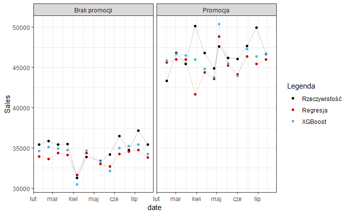

```r
# Wykres dla predykcji
test_weekly_stats <- test_data_weeks %>%
    ungroup() %>%
    mutate(Promo = ifelse(Promo_real > 0.5, "Promocja", "Brak promocji")) %>%
    group_by(week_num, Promo) %>%
    summarise(Sales = mean(Sales), prediction_fe = mean(prediction_fe, na.rm = T),
              prediction_xgb = mean(prediction_xgb, na.rm = T),
              date = min(date))

ggplot(test_weekly_stats, aes(x = date, y = Sales))+
    geom_point(aes(color = "1"))+
    geom_point(aes(x = date, y = prediction_fe, color = "2"))+
    geom_point(aes(x = date, y = prediction_xgb, color = "3"))+
    geom_line(alpha = .2)+
    geom_line(aes(x = date, y = prediction_fe), color = "red3", alpha = .2)+
    geom_line(aes(x = date, y = prediction_xgb), color = "#56B4E9", alpha = .2)+
    facet_wrap(~Promo)+
    scale_color_manual(values = c("black", "red3", "#56B4E9"),
                       labels = c("Rzeczywistość", "Regresja", "XGBoost"),
                       name = "Legenda")+
    theme_bw()
```